# Alligator Harbor Aquatic Preserve

SEACAR Habitat Analyses

Last compiled on 10 June, 2026

# Funding & Acknowledgements

The data used in this analysis is from the Export Standardized Tables in the SEACAR Data Discovery Interface (DDI). Documents and information available through the SEACAR DDI are owned by the data provider(s) and users are expected to provide appropriate credit following accepted citation formats. Users are encouraged to access data to maximize utilization of gained knowledge, reducing redundant research and facilitating partnerships and scientific innovation.

With respect to documents and information available from SEACAR DDI, neither the State of Florida nor the Florida Department of Environmental Protection makes any warranty, expressed or implied, including the warranties of merchantability and fitness for a particular purpose arising out of the use or inability to use the data, or assumes any legal liability or responsibility for the accuracy, completeness, or usefulness of any information, apparatus, product, or process disclosed, or represents that its use would not infringe privately owned rights.

This report was funded in part, through a grant agreement from the Florida Department of Environmental Protection, Florida Coastal Management Program, by a grant provided by the Office for Coastal Management under the Coastal Zone Management Act of 1972, as amended, National Oceanic and Atmospheric Administration. The views, statements, findings, conclusions and recommendations expressed herein are those of the author(s) and do not necessarily reflect the views of the State of Florida, NOAA or any of their sub agencies.

**Published**: 2026-06-10

[figure not shown]

# Threshold Filtering

Threshold filters, following the guidance of Florida Department of Environmental Protection’s (*FDEP*) Division of Environmental Assessment and Restoration (*DEAR*) are used to exclude specific results values from the SEACAR Analysis. Based on the threshold filters, Quality Assurance / Quality Control (*QAQC*) Flags are inserted into the *SEACAR_QAQCFlagCode* and *SEACAR_QAQC_Description* columns of the export data. The *Include* column indicates whether the *QAQC* Flag will also indicate that data are excluded from analysis. No data are excluded from the data export, but the analysis scripts can use the *Include* column to exclude data (1 to include, 0 to exclude).

Continuous Water Quality threshold values

| *Parameter Name* | *Units* | *Low Threshold* | *High Threshold* |
| --- | --- | --- | --- |
| Chlorophyll a, Uncorrected for Pheophytin | ug/L | - | - |
| Dissolved Oxygen | mg/L | -0.000001 | 50 |
| Dissolved Oxygen Saturation | % | -0.000001 | 500 |
| Fluorescent Dissolved Organic Matter | QSE | - | - |
| Salinity | ppt | -0.000001 | 70 |
| Specific Conductivity | mS/cm | -0.000001 | 200 |
| Turbidity | NTU | -0.000001 | 4000 |
| Water Temperature | Degrees C | -5.000000 | 45 |
| pH | None | 2.000000 | 14 |

Discrete Water Quality threshold values

| *Parameter Name* | *Units* | *Low Threshold* | *High Threshold* |
| --- | --- | --- | --- |
| Ammonia, Un-ionized (NH3) | mg/L | - | - |
| Ammonium (NH4) | mg/L | - | - |
| Chlorophyll a, Corrected for Pheophytin | ug/L | - | - |
| Chlorophyll a, Uncorrected for Pheophytin | ug/L | - | - |
| Colored Dissolved Organic Matter | PCU | - | - |
| Dissolved Oxygen | mg/L | -0.000001 | 25 |
| Dissolved Oxygen Saturation | % | -0.000001 | 310 |
| Fluorescent Dissolved Organic Matter | QSE | - | - |
| Light Extinction Coefficient | m^-1 | - | - |
| NO2+3, Filtered | mg/L | - | - |
| Nitrate (NO3) | mg/L | - | - |
| Nitrite (NO2) | mg/L | - | - |
| Nitrogen, inorganic | mg/L | - | - |
| Nitrogen, organic | mg/L | - | - |
| Phosphate, Filtered (PO4) | mg/L | - | - |
| Salinity | ppt | -0.000001 | 70 |
| Secchi Depth | m | 0.000001 | 50 |
| Specific Conductivity | mS/cm | 0.005000 | 100 |
| Total Ammonia (N) | mg/L | - | - |
| Total Kjeldahl Nitrogen | mg/L | - | - |
| Total Nitrogen | mg/L | - | - |
| Total Nitrogen | mg/L | - | - |
| Total Phosphorus | mg/L | - | - |
| Total Suspended Solids | mg/L | - | - |
| Turbidity | NTU | - | - |
| Water Temperature | Degrees C | 3.000000 | 40 |
| pH | None | 2.000000 | 13 |

Quality Assurance Flags inserted based on threshold checks listed in Table 1 and 2

| *SEACAR QAQC Description* | *Include* | *SEACAR QAQCFlagCode* |
| --- | --- | --- |
| Exceeds maximum threshold | 0 | 2Q |
| Below minimum threshold | 0 | 4Q |
| Within threshold tolerance | 1 | 6Q |
| No defined thresholds for this parameter | 1 | 7Q |

# Value Qualifiers

Value qualifier codes included within the data are used to exclude certain results from the analysis. The data are retained in the data export files, but the analysis uses the *Include* column to filter the results.

**STORET and WIN value qualifier codes**

Value qualifier codes from *STORET* and *WIN* data are examined with the database and used to populate the *Include* column in data exports.

Value Qualifier codes excluded from analysis

| *Qualifier Source* | *Value Qualifier* | *Include* | *MDL* | *Description* |
| --- | --- | --- | --- | --- |
| STORET-WIN | H | 0 | 0 | Value based on field kit determination; results may not be accurate |
| STORET-WIN | J | 0 | 0 | Estimated value |
| STORET-WIN | V | 0 | 0 | Analyte was detected at or above method detection limit |
| STORET-WIN | Y | 0 | 0 | Lab analysis from an improperly preserved sample; data may be inaccurate |

**Discrete Water Quality Value Qualifiers**

The following value qualifiers are highlighted in the Discrete Water Quality section of this report. An exception is made for **Program 476** - *Charlotte Harbor Estuaries Volunteer Water Quality Monitoring Network* and data flagged with Value Qualifier **H** are included for this program only.

**H** - Value based on field kit determiniation; results may not be accurate. This code shall be used if a field screening test (e.g., field gas chromatograph data, immunoassay, or vendor-supplied field kit) was used to generate the value and the field kit or method has not been recognized by the Department as equivalent to laboratory methods.

**I** - The reported value is greater than or equal to the laboratory method detection limit but less than the laboratory practical quantitation limit.

**Q** - Sample held beyond the accepted holding time. This code shall be used if the value is derived from a sample that was prepared or analyzed after the approved holding time restrictions for sample preparation or analysis.

**S** - Secchi disk visible to bottom of waterbody. The value reported is the depth of the waterbody at the location of the Secchi disk measurement.

**U** - Indicates that the compound was analyzed for but not detected. This symbol shall be used to indicate that the specified component was not detected. The value associated with the qualifier shall be the laboratory method detection limit. Unless requested by the client, less than the method detection limit values shall not be reported

**Systemwide Monitoring Program (SWMP) value qualifier codes**

Value qualifier codes from the *SWMP* continuous program are examined with the database and used to populate the *Include* column in data exports. *SWMP* Qualifier Codes are indicated by *QualifierSource=SWMP*.

SWMP Value Qualifier codes

| *Qualifier Source* | *Value Qualifier* | *Include* | *Description* |
| --- | --- | --- | --- |
| SWMP | -1 | 1 | Optional parameter not collected |
| SWMP | -2 | 0 | Missing data |
| SWMP | -3 | 0 | Data rejected due to QA/QC |
| SWMP | -4 | 0 | Outside low sensor range |
| SWMP | -5 | 0 | Outside high sensor range |
| SWMP | 0 | 1 | Passed initial QA/QC checks |
| SWMP | 1 | 0 | Suspect data |
| SWMP | 2 | 1 | Reserved for future use |
| SWMP | 3 | 1 | Calculated data: non-vented depth/level sensorcorrection for changes in barometric pressure |
| SWMP | 4 | 1 | Historical: Pre-auto QA/QC |
| SWMP | 5 | 1 | Corrected data |

# Water Column

The water column habitat extends from the water’s surface to the bottom sediments, and it’s where fish, dolphins, crabs and people swim! So much life makes its home in the water column that the health of marine and coastal ecosystems, as well as human economies, depend on the condition of this vulnerable habitat. Local patterns of rainfall, temperature, winds and currents can rapidly change the condition of the water column, while global influences such as [El Niño/La Niña](https://oceanservice.noaa.gov/facts/ninonina.html), large-scale fluctuation in sea temperatures and climate change can have long-term effects. Inputs from the prosperity of our day-to-day lives including farming, mining and forestry, and emissions from power generation, automobiles and water treatment can also alter the health of the water column. Acting alone or together, each input can have complex and lasting effects on habitats and ecosystems.

SEACAR evaluates water column health with several essential parameters. These include nutrient surveys of nitrogen and phosphorus, and water quality assessments of salinity, dissolved oxygen, pH, and water temperature. Water clarity is evaluated with Secchi depth, turbidity, levels of chlorophyll a, total suspended solids, and colored dissolved organic matter. Additionally, the richness of nekton is indicated by the abundance of free-swimming fishes and macroinvertebrates like crabs and shrimps.

# Seasonal Kendall-Tau Analysis

Indicators must have a minimum of five to ten years, depending on the habitat, of data within the geographic range of the analysis to be included in the analysis. Ten years of data are required for discrete parameters, and five years of data are required for continuous parameters. If there are insufficient years of data, the number of years of data available will be noted and labeled as “insufficient data to conduct analysis”. Further, for the preferred Seasonal Kendall-Tau test, there must be data from at least two months in common across at least two consecutive years within the RCP managed area being analyzed. Values that pass both of these tests will be included in the analysis and be labeled as *Use_In_Analysis* = **TRUE**. Any that fail either test will be excluded from the analyses and labeled as *Use_In_Analysis* = **FALSE**. The points for all Water Column plots displayed in this section are monthly averages. Trend significance will be denoted as “Significant Trend” (when p < 0.05), or “Non-significant Trend” (when p >= 0.05). Any parameters with insufficient data to perform Seasonal Kendall-Tau test will have their monthly averages plotted without a corresponding trend line.

# Water Quality - Discrete

The following files were used in the discrete analysis:

- *Combined_WQ_WC_NUT_Chlorophyll_a_corrected_for_pheophytin-2026-May-18.txt*
- *Combined_WQ_WC_NUT_Chlorophyll_a_uncorrected_for_pheophytin-2026-May-18.txt*
- *Combined_WQ_WC_NUT_Colored_dissolved_organic_matter_CDOM-2026-May-18.txt*
- *Combined_WQ_WC_NUT_Dissolved_Oxygen-2026-May-18.txt*
- *Combined_WQ_WC_NUT_Dissolved_Oxygen_Saturation-2026-May-18.txt*
- *Combined_WQ_WC_NUT_pH-2026-May-18.txt*
- *Combined_WQ_WC_NUT_Salinity-2026-May-18.txt*
- *Combined_WQ_WC_NUT_Secchi_Depth-2026-May-18.txt*
- *Combined_WQ_WC_NUT_Total_Nitrogen-2026-May-18.txt*
- *Combined_WQ_WC_NUT_Total_Phosphorus-2026-May-18.txt*
- *Combined_WQ_WC_NUT_Total_Suspended_Solids_TSS-2026-May-18.txt*
- *Combined_WQ_WC_NUT_Turbidity-2026-May-18.txt*
- *Combined_WQ_WC_NUT_Water_Temperature-2026-May-18.txt*

## Chlorophyll a, Corrected for Pheophytin - Discrete

**Seasonal Kendall-Tau Trend Analysis**

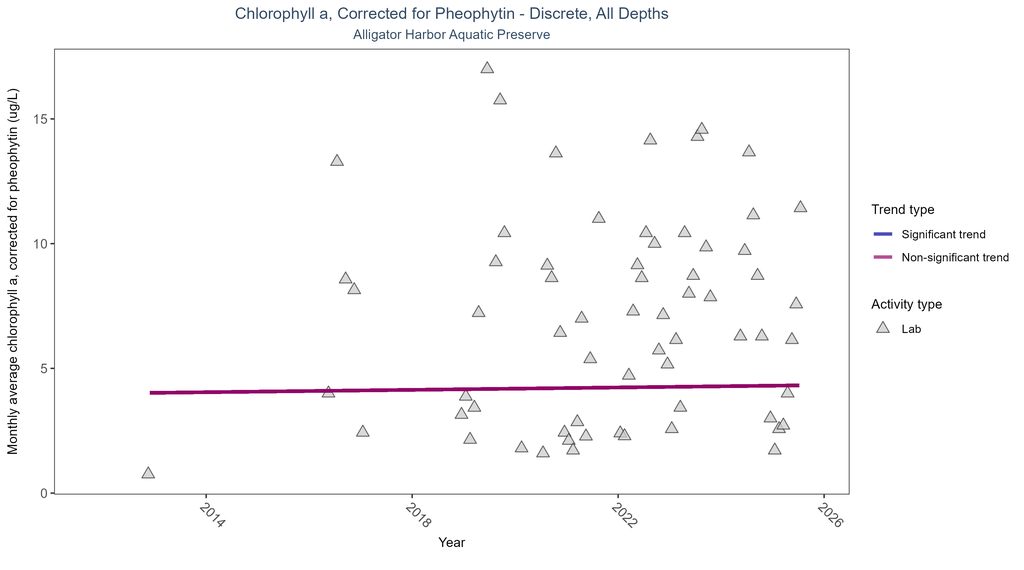

Scatter plot of monthly average levels of chlorophyll a, corrected for pheophytin, over time. If the time series included ten or more years of discrete observations, a significant (blue) or non-significant (magenta) trend line is also shown. Only laboratory-analyzed chlorophyll a (triangles) is included in the plot.

Seasonal Kendall-Tau Trend Analysis for Chlorophyll a, Corrected for Pheophytin

| Activity Type | Statistical Trend | No. of Samples | No. Years with Data | Period of Record | Median Result Value | Tau | Sen Intercept | Sen Slope | P |
| --- | --- | --- | --- | --- | --- | --- | --- | --- | --- |
| Lab | No detectable trend | 436 | 11 | 2012 - 2025 | 5.9 | 0.059 | 3.9958 | 0.0238 | 0.5801 |

Chlorophyll a, corrected for pheophytin, showed no detectable trend between 2012 and 2025.

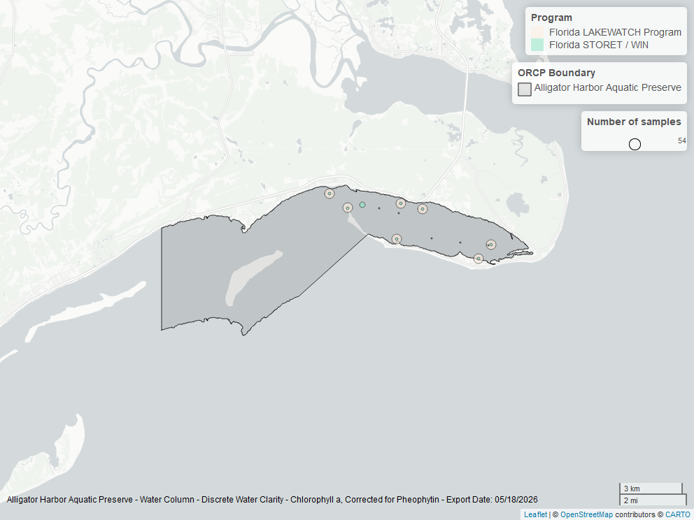

Map showing location of discrete water quality sampling locations within the boundaries of *Alligator Harbor Aquatic Preserve*. The bubble size on the maps above reflect the amount of data available at each sampling site.

Programs contributing data for Chlorophyll a, Corrected for Pheophytin

| ProgramID | N_Data | YearMin | YearMax |
| --- | --- | --- | --- |
| 514 | 377 | 2018 | 2025 |
| 5002 | 59 | 2012 | 2022 |

**Program names:**

*514* - Florida LAKEWATCH Program<sup>1</sup>  
*5002* - Florida STORET / WIN<sup>2</sup>

## Chlorophyll a, Uncorrected for Pheophytin - Discrete

**Seasonal Kendall-Tau Trend Analysis**

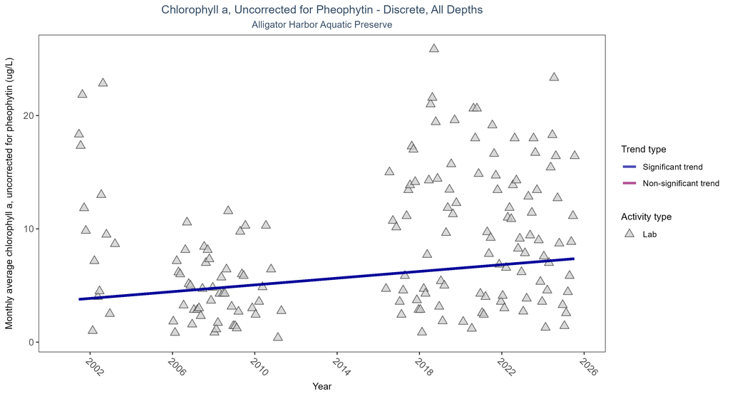

Scatter plot of monthly average levels of chlorophyll a, uncorrected for pheophytin, over time. If the time series included ten or more years of discrete observations, a significant (blue) or non-significant (magenta) trend line is also shown. Only laboratory-analyzed chlorophyll a (triangles) is included in the plot.

Seasonal Kendall-Tau Trend Analysis for Chlorophyll a, Uncorrected for Pheophytin

| Activity Type | Statistical Trend | No. of Samples | No. Years with Data | Period of Record | Median Result Value | Tau | Sen Intercept | Sen Slope | P |
| --- | --- | --- | --- | --- | --- | --- | --- | --- | --- |
| Lab | Increasing trend | 1178 | 19 | 2001 - 2025 | 6 | 0.2711 | 3.712 | 0.1488 | 0 |

Monthly average chlorophyll a, uncorrected for pheophytin, increased by 0.15 µg/L per year, indicating a decrease in water clarity.

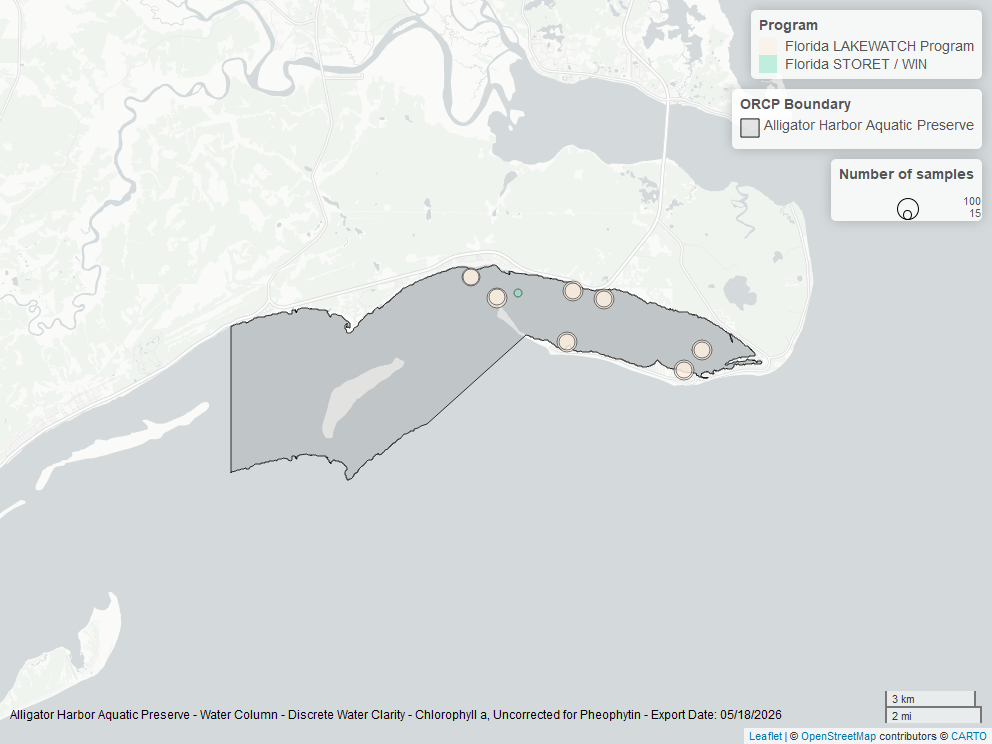

Map showing location of discrete water quality sampling locations within the boundaries of *Alligator Harbor Aquatic Preserve*. The bubble size on the maps above reflect the amount of data available at each sampling site.

Programs contributing data for Chlorophyll a, Uncorrected for Pheophytin

| ProgramID | N_Data | YearMin | YearMax |
| --- | --- | --- | --- |
| 514 | 1159 | 2001 | 2025 |
| 5002 | 19 | 2019 | 2022 |

**Program names:**

*514* - Florida LAKEWATCH Program<sup>1</sup>  
*5002* - Florida STORET / WIN<sup>2</sup>

## Colored Dissolved Organic Matter - Discrete

**Seasonal Kendall-Tau Trend Analysis**

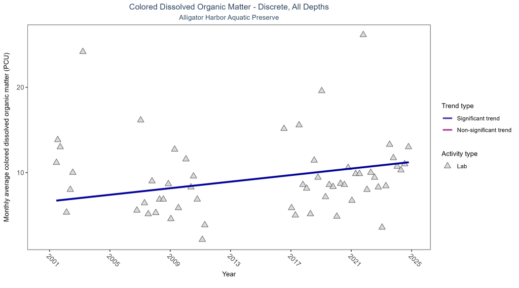

Scatter plot of monthly average colored dissolved organic matter (CDOM) over time. If the time series included ten or more years of discrete observations, a significant (blue) or non-significant (magenta) trend line is also shown. Only laboratory-analyzed CDOM (triangles) is included in the plot.

Seasonal Kendall-Tau Trend Analysis for Colored Dissolved Organic Matter

| Activity Type | Statistical Trend | No. of Samples | No. Years with Data | Period of Record | Median Result Value | Tau | Sen Intercept | Sen Slope | P |
| --- | --- | --- | --- | --- | --- | --- | --- | --- | --- |
| Lab | Increasing trend | 423 | 18 | 2001 - 2024 | 8 | 0.232 | 6.6296 | 0.1922 | 0.0315 |

Monthly average colored dissolved organic matter increased by 0.19 PCU per year, indicating a decrease in water clarity.

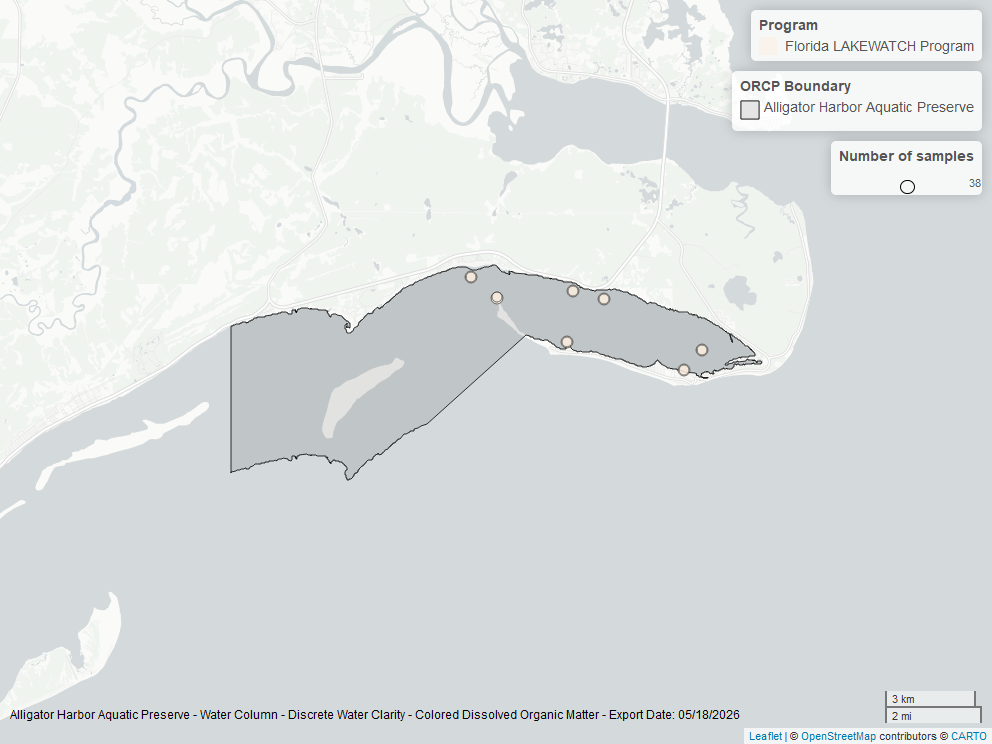

Map showing location of discrete water quality sampling locations within the boundaries of *Alligator Harbor Aquatic Preserve*. The bubble size on the maps above reflect the amount of data available at each sampling site.

Programs contributing data for Colored Dissolved Organic Matter

| ProgramID | N_Data | YearMin | YearMax |
| --- | --- | --- | --- |
| 514 | 423 | 2001 | 2024 |

**Program names:**

*514* - Florida LAKEWATCH Program<sup>1</sup>

## Dissolved Oxygen - Discrete

**Seasonal Kendall-Tau Trend Analysis**

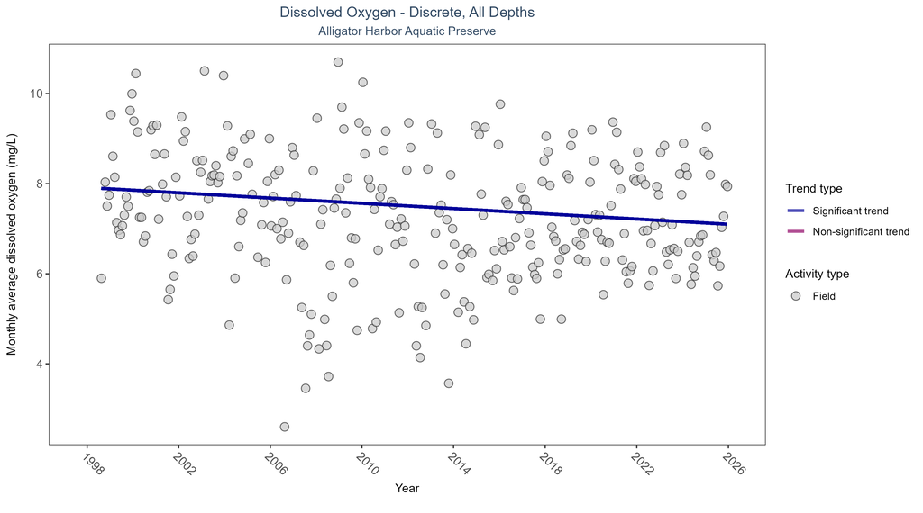

Scatter plot of monthly average dissolved oxygen over time. If the time series included ten or more years of discrete observations, a significant (blue) or non-significant (magenta) trend line is also shown. Only dissolved oxygen values measured in the field (circles) are included in the plot.

Seasonal Kendall-Tau Trend Analysis for Dissolved Oxygen

| Activity Type | Statistical Trend | No. of Samples | No. Years with Data | Period of Record | Median Result Value | Tau | Sen Intercept | Sen Slope | P |
| --- | --- | --- | --- | --- | --- | --- | --- | --- | --- |
| Field | Decreasing trend | 8423 | 28 | 1998 - 2025 | 7.2 | -0.1683 | 7.9129 | -0.0291 | 0 |

Monthly average dissolved oxygen decreased by 0.03 mg/L per year.

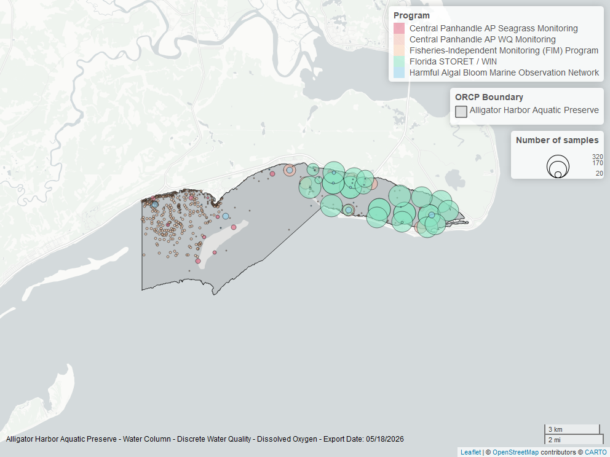

Map showing location of discrete water quality sampling locations within the boundaries of *Alligator Harbor Aquatic Preserve*. The bubble size on the maps above reflect the amount of data available at each sampling site.

Programs contributing data for Dissolved Oxygen

| ProgramID | N_Data | YearMin | YearMax |
| --- | --- | --- | --- |
| 5002 | 5829 | 1998 | 2022 |
| 69 | 1478 | 1998 | 2024 |
| 469 | 770 | 2016 | 2025 |
| 557 | 191 | 2005 | 2023 |
| 95 | 156 | 2004 | 2018 |

**Program names:**

*5002* - Florida STORET / WIN<sup>2</sup>  
*69* - Fisheries-Independent Monitoring (FIM) Program<sup>3</sup>  
*469* - Central Panhandle Aquatic Preserve WQ Monitoring<sup>4</sup>  
*557* - Central Panhandle Aquatic Preserves Seagrass Monitoring<sup>5</sup>  
*95* - Harmful Algal Bloom Marine Observation Network<sup>6</sup>

## pH - Discrete

**Seasonal Kendall-Tau Trend Analysis**

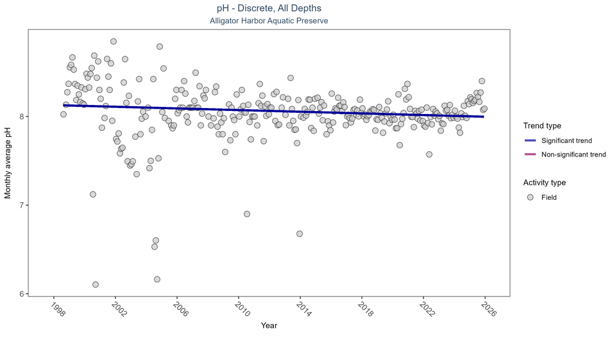

Scatter plot of monthly average pH over time. If the time series included ten or more years of discrete observations, a significant (blue) or non-significant (magenta) trend line is also shown. Only pH values measured in the field (circles) are included in the plot.

Seasonal Kendall-Tau Trend Analysis for pH

| Activity Type | Statistical Trend | No. of Samples | No. Years with Data | Period of Record | Median Result Value | Tau | Sen Intercept | Sen Slope | P |
| --- | --- | --- | --- | --- | --- | --- | --- | --- | --- |
| Field | Decreasing trend | 5534 | 28 | 1998 - 2025 | 8.1 | -0.1142 | 8.129 | -0.0047 | 0.0052 |

Monthly average pH decreased by less than 0.01 pH units per year.

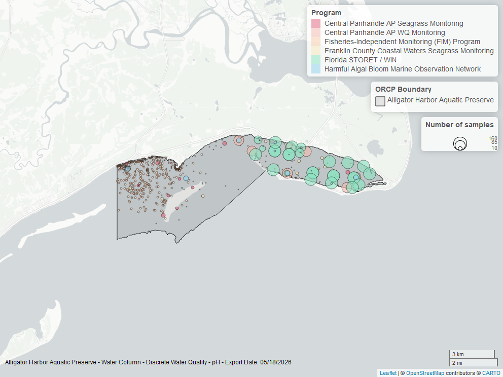

Map showing location of discrete water quality sampling locations within the boundaries of *Alligator Harbor Aquatic Preserve*. The bubble size on the maps above reflect the amount of data available at each sampling site.

Programs contributing data for pH

| ProgramID | N_Data | YearMin | YearMax |
| --- | --- | --- | --- |
| 5002 | 2810 | 1998 | 2022 |
| 69 | 1454 | 1998 | 2024 |
| 469 | 770 | 2016 | 2025 |
| 558 | 180 | 2008 | 2014 |
| 557 | 170 | 2005 | 2023 |
| 95 | 152 | 2008 | 2018 |

**Program names:**

*5002* - Florida STORET / WIN<sup>2</sup>  
*69* - Fisheries-Independent Monitoring (FIM) Program<sup>3</sup>  
*469* - Central Panhandle Aquatic Preserve WQ Monitoring<sup>4</sup>  
*558* - Franklin County Coastal Waters Seagrass Monitoring<sup>7</sup>  
*557* - Central Panhandle Aquatic Preserves Seagrass Monitoring<sup>5</sup>  
*95* - Harmful Algal Bloom Marine Observation Network<sup>6</sup>

## Salinity - Discrete

**Seasonal Kendall-Tau Trend Analysis**

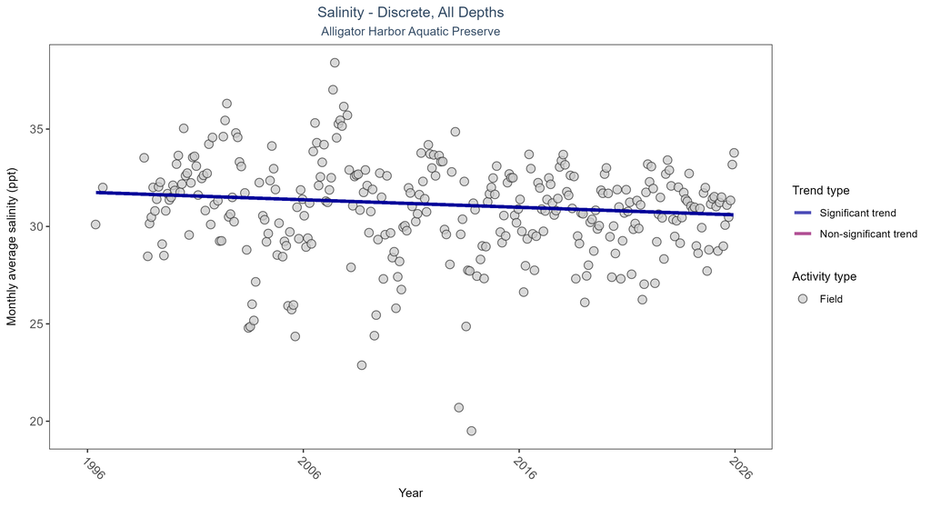

Scatter plot of monthly average salinity over time. If the time series included ten or more years of discrete observations, significant (blue) or non-significant (magenta) trend lines are also shown. Discrete salinity values derived from grab samples analyzed in the field (circles) or the laboratory (triangles) are both included in the plot.

Seasonal Kendall-Tau Trend Analysis for Salinity

| Activity Type | Statistical Trend | No. of Samples | No. Years with Data | Period of Record | Median Result Value | Tau | Sen Intercept | Sen Slope | P |
| --- | --- | --- | --- | --- | --- | --- | --- | --- | --- |
| All | Decreasing trend | 9675 | 29 | 1996 - 2025 | 31.11 | -0.107 | 31.7577 | -0.0387 | 0.0072 |

Monthly average salinity decreased by 0.04 ppt per year.

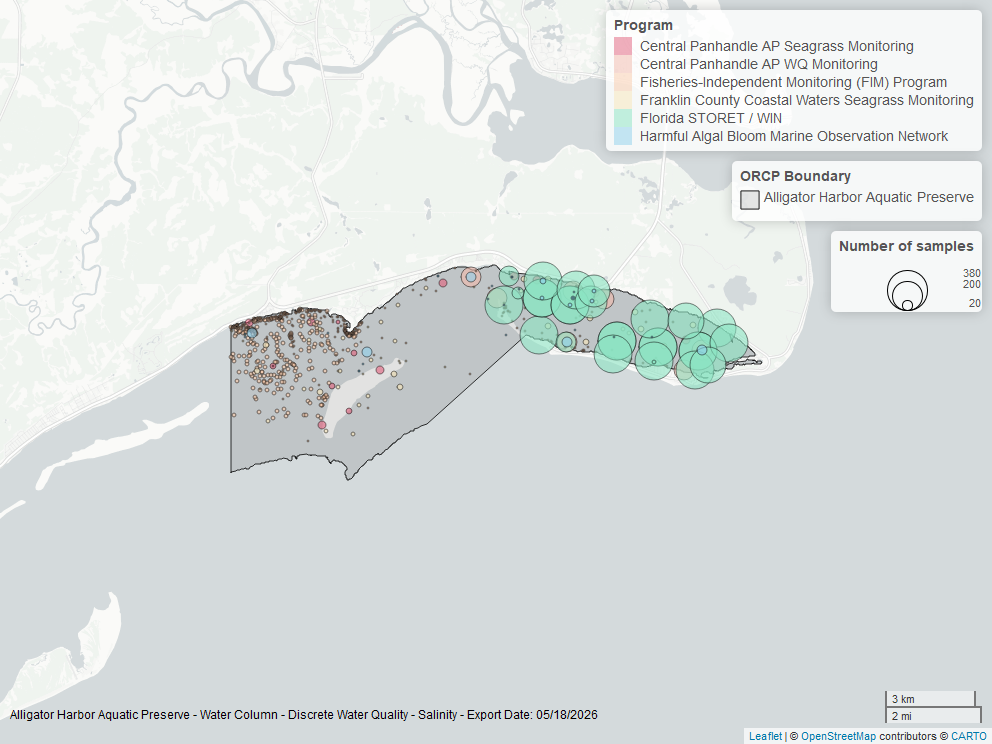

Map showing location of discrete water quality sampling locations within the boundaries of *Alligator Harbor Aquatic Preserve*. The bubble size on the maps above reflect the amount of data available at each sampling site.

Programs contributing data for Salinity

| ProgramID | N_Data | YearMin | YearMax |
| --- | --- | --- | --- |
| 5002 | 6810 | 1998 | 2022 |
| 69 | 1476 | 1998 | 2024 |
| 469 | 770 | 2016 | 2025 |
| 558 | 258 | 2008 | 2014 |
| 557 | 191 | 2005 | 2023 |
| 95 | 171 | 1996 | 2018 |

**Program names:**

*5002* - Florida STORET / WIN<sup>2</sup>  
*69* - Fisheries-Independent Monitoring (FIM) Program<sup>3</sup>  
*469* - Central Panhandle Aquatic Preserve WQ Monitoring<sup>4</sup>  
*558* - Franklin County Coastal Waters Seagrass Monitoring<sup>7</sup>  
*557* - Central Panhandle Aquatic Preserves Seagrass Monitoring<sup>5</sup>  
*95* - Harmful Algal Bloom Marine Observation Network<sup>6</sup>

## Total Nitrogen - Discrete

**Total Nitrogen Calculation:**

The logic for calculated Total Nitrogen was provided by Kevin O’Donnell and colleagues at FDEP (with the help of Jay Silvanima, Watershed Monitoring Section). The following logic is used, in this order, based on the availability of specific nitrogen components.

1. TN = TKN + NO3O2;
2. TN = TKN + NO3 + NO2;
3. TN = ORGN + NH4 + NO3O2;
4. TN = ORGN + NH4 + NO2 + NO3;
5. TN = TKN + NO3;
6. TN = ORGN + NH4 + NO3;

Additional Information:

- Rules for use of sample fraction:
  - Florida Department of Environmental Protection (FDEP) report that if both “Total” and “Dissolved” components are reported, only “Total” is used. If the total is not reported, then the dissolved components are used as a best available replacement.
  - Total nitrogen calculations are done using nitrogen components with the same sample fraction, nitrogen components with mixed total/dissolved sample fractions are not used. In other words, total nitrogen can be calculated when TKN and NO3O2 are both total sample fractions, or when both are dissolved sample fractions. *Future calculations of total nitrogen values may be based on components with mixed sample fractions.*
- Values inserted into data:
  - ParameterName = “Total Nitrogen”
  - SEACAR_QAQCFlagCode = “1Q”
  - SEACAR_QAQC_Description = “SEACAR Calculated”

**Seasonal Kendall-Tau Trend Analysis**

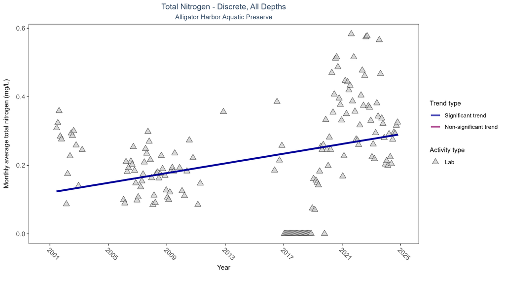

Scatter plot of monthly average total nitrogen over time. If the time series included ten or more years of discrete observations, a significant (blue) or non-significant (magenta) trend line is also shown. Only nitrogen values obtained from laboratory analyses (triangles) are included in the plot.

Seasonal Kendall-Tau Trend Analysis for Total Nitrogen

| Activity Type | Statistical Trend | No. of Samples | No. Years with Data | Period of Record | Median Result Value | Tau | Sen Intercept | Sen Slope | P |
| --- | --- | --- | --- | --- | --- | --- | --- | --- | --- |
| Lab | Increasing trend | 1625 | 19 | 2001 - 2024 | 0.2 | 0.279 | 0.1205 | 0.0071 | 0 |

Monthly average total nitrogen increased by 0.01 mg/L per year.

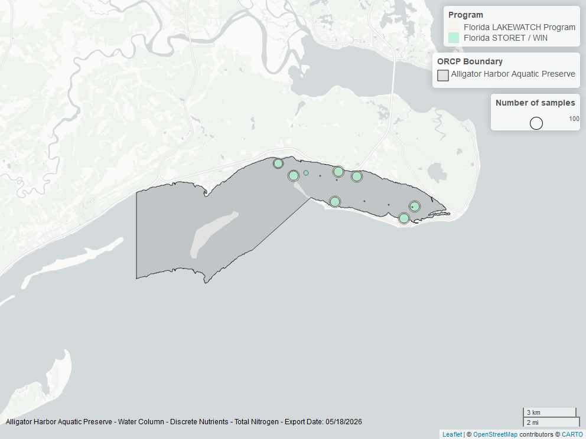

Map showing location of discrete water quality sampling locations within the boundaries of *Alligator Harbor Aquatic Preserve*. The bubble size on the maps above reflect the amount of data available at each sampling site.

Programs contributing data for Total Nitrogen

| ProgramID | N_Data | YearMin | YearMax |
| --- | --- | --- | --- |
| 514 | 1175 | 2001 | 2024 |
| 5002 | 465 | 2001 | 2022 |

**Program names:**

*514* - Florida LAKEWATCH Program<sup>1</sup>  
*5002* - Florida STORET / WIN<sup>2</sup>

## Total Phosphorus - Discrete

**Seasonal Kendall-Tau Trend Analysis**

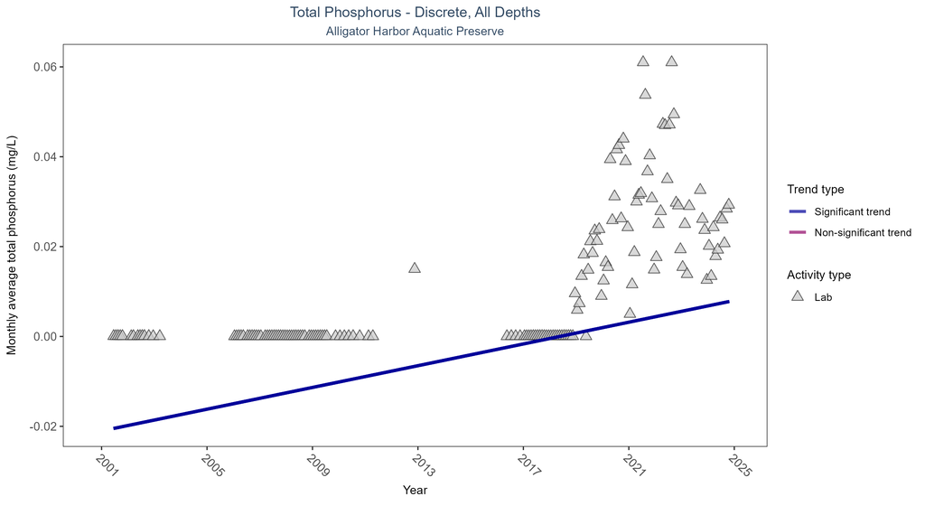

Scatter plot of monthly average total phosphorus over time. If the time series included ten or more years of discrete observations, a significant (blue) or non-significant (magenta) trend line is also shown. Only phosphorus values obtained from laboratory analyses (triangles) are included in the plot.

Seasonal Kendall-Tau Trend Analysis for Total Phosphorus

[output not shown]

Monthly average total phosphorus increased by less than 0.01 mg/L per year.

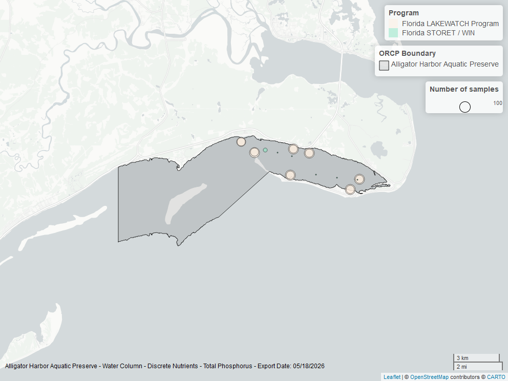

Map showing location of discrete water quality sampling locations within the boundaries of *Alligator Harbor Aquatic Preserve*. The bubble size on the maps above reflect the amount of data available at each sampling site.

Programs contributing data for Total Phosphorus

| ProgramID | N_Data | YearMin | YearMax |
| --- | --- | --- | --- |
| 514 | 1149 | 2001 | 2024 |
| 5002 | 24 | 2012 | 2022 |

**Program names:**

*514* - Florida LAKEWATCH Program<sup>1</sup>  
*5002* - Florida STORET / WIN<sup>2</sup>

## Turbidity - Discrete

**Seasonal Kendall-Tau Trend Analysis**

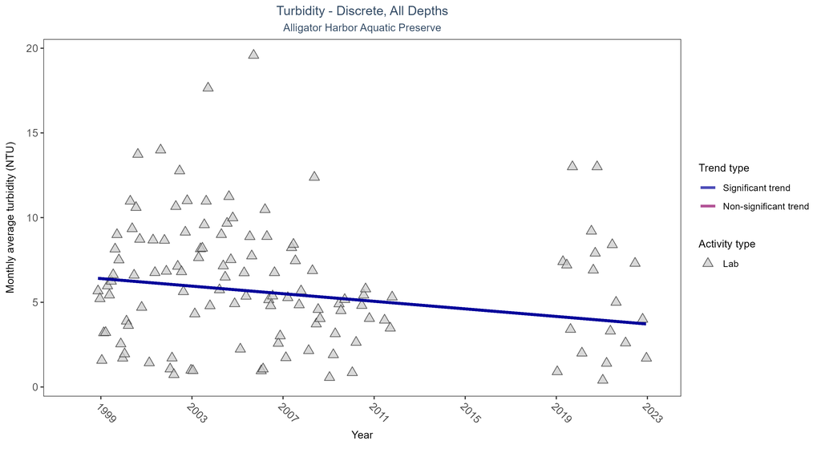

Scatter plot of monthly average turbidity over time. If the time series included ten or more years of discrete observations, a significant (blue) or non-significant (magenta) trend line is also shown. Only turbidity values measured in the laboratory (triangles) are included in the plot.

Seasonal Kendall-Tau Trend Analysis for Turbidity

| Activity Type | Statistical Trend | No. of Samples | No. Years with Data | Period of Record | Median Result Value | Tau | Sen Intercept | Sen Slope | P |
| --- | --- | --- | --- | --- | --- | --- | --- | --- | --- |
| Lab | Decreasing trend | 3543 | 18 | 1998 - 2022 | 5.3 | -0.2432 | 6.5131 | -0.1119 | 0.0012 |

Monthly average turbidity decreased by 0.11 NTU per year, indicating an increase in water clarity.

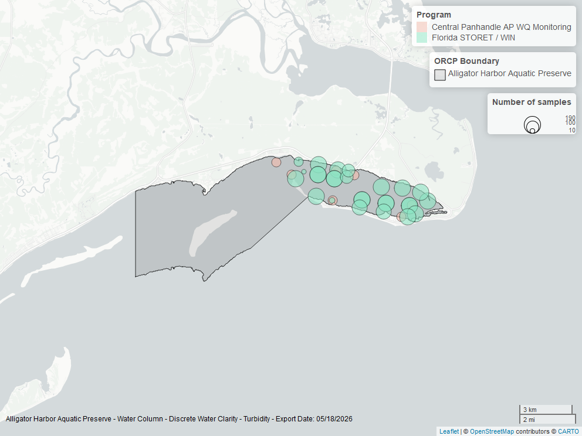

Map showing location of discrete water quality sampling locations within the boundaries of *Alligator Harbor Aquatic Preserve*. The bubble size on the maps above reflect the amount of data available at each sampling site.

Programs contributing data for Turbidity

| ProgramID | N_Data | YearMin | YearMax |
| --- | --- | --- | --- |
| 5002 | 3543 | 1998 | 2022 |
| 469 | 399 | 2021 | 2025 |

**Program names:**

*5002* - Florida STORET / WIN<sup>2</sup>  
*469* - Central Panhandle Aquatic Preserve WQ Monitoring<sup>4</sup>

## Water Temperature - Discrete

**Seasonal Kendall-Tau Trend Analysis**

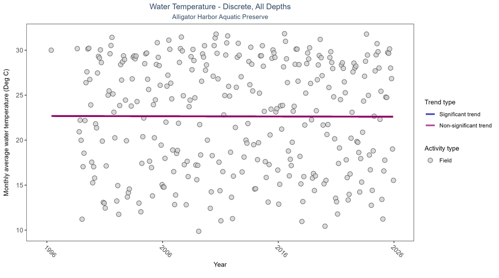

Scatter plot of monthly average water temperature over time. If the time series included ten or more years of discrete observations, a significant (blue) or non-significant (magenta) trend line is also shown. Only water temperature measurements taken in the field (circles) are included in the plot.

Seasonal Kendall-Tau Trend Analysis for Water Temperature

| Activity Type | Statistical Trend | No. of Samples | No. Years with Data | Period of Record | Median Result Value | Tau | Sen Intercept | Sen Slope | P |
| --- | --- | --- | --- | --- | --- | --- | --- | --- | --- |
| Field | No detectable trend | 9916 | 29 | 1996 - 2025 | 25.9 | -0.0061 | 22.6848 | -0.0026 | 0.8755 |

Water temperature showed no detectable trend between 1996 and 2025.

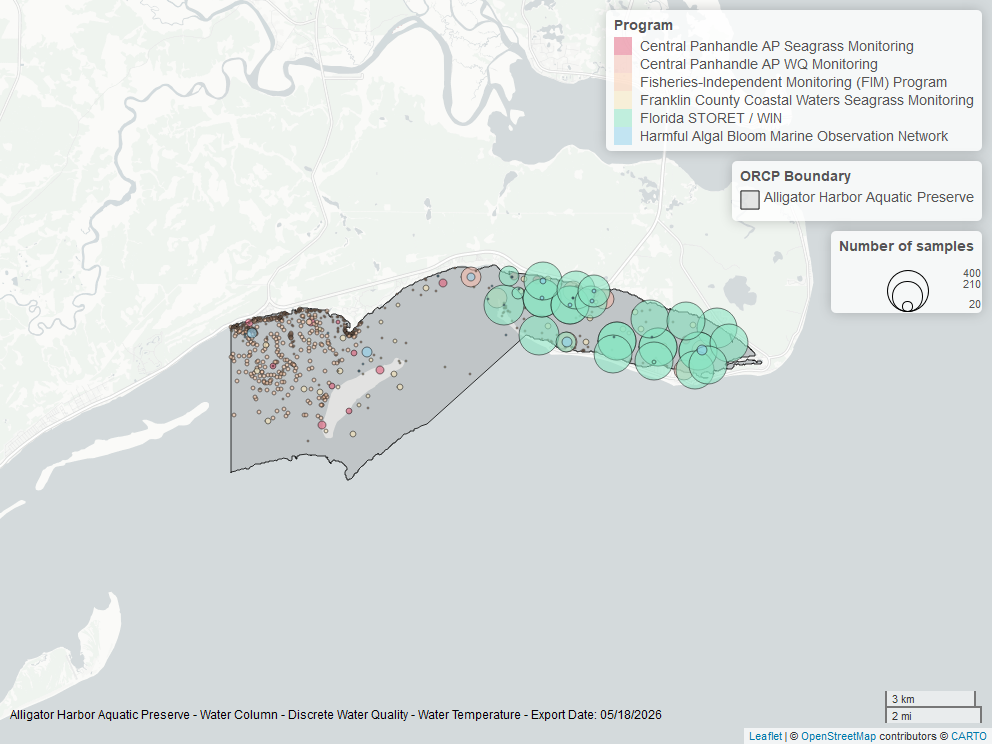

Map showing location of discrete water quality sampling locations within the boundaries of *Alligator Harbor Aquatic Preserve*. The bubble size on the maps above reflect the amount of data available at each sampling site.

Programs contributing data for Water Temperature

| ProgramID | N_Data | YearMin | YearMax |
| --- | --- | --- | --- |
| 5002 | 7037 | 1998 | 2022 |
| 69 | 1482 | 1998 | 2024 |
| 469 | 770 | 2016 | 2025 |
| 558 | 271 | 2008 | 2017 |
| 557 | 191 | 2005 | 2023 |
| 95 | 166 | 1996 | 2018 |

**Program names:**

*5002* - Florida STORET / WIN<sup>2</sup>  
*69* - Fisheries-Independent Monitoring (FIM) Program<sup>3</sup>  
*469* - Central Panhandle Aquatic Preserve WQ Monitoring<sup>4</sup>  
*558* - Franklin County Coastal Waters Seagrass Monitoring<sup>7</sup>  
*557* - Central Panhandle Aquatic Preserves Seagrass Monitoring<sup>5</sup>  
*95* - Harmful Algal Bloom Marine Observation Network<sup>6</sup>

# Water Quality - Continuous

The following files were used in the continuous analysis:

- *Combined_WQ_WC_NUT_cont_Chlorophyll_a_Uncorrected_for_Pheophytin-2026-Mar-06.txt*
- *Combined_WQ_WC_NUT_cont_Dissolved_Oxygen-2026-Mar-06.txt*
- *Combined_WQ_WC_NUT_cont_Dissolved_Oxygen_Saturation-2026-Mar-06.txt*
- *Combined_WQ_WC_NUT_cont_Fluorescent_Dissolved_Organic_Matter-2026-Mar-06.txt*
- *Combined_WQ_WC_NUT_cont_pH-2026-Mar-06.txt*
- *Combined_WQ_WC_NUT_cont_Salinity-2026-Mar-06.txt*
- *Combined_WQ_WC_NUT_cont_Specific_Conductivity-2026-Mar-06.txt*
- *Combined_WQ_WC_NUT_cont_Turbidity-2026-Mar-06.txt*
- *Combined_WQ_WC_NUT_cont_Water_Temperature-2026-Mar-06.txt*

**Continuous monitoring locations in Alligator Harbor Aquatic Preserve**

Station overview for Continuous parameters by Program

| ProgramID | ProgramLocationID | Years of Data | Use in Analysis | Parameters |
| --- | --- | --- | --- | --- |
| 468 | CPAH | 2 | FALSE | pH , Dissolved Oxygen Saturation, Dissolved Oxygen , Turbidity , Water Temperature , Salinity , Specific Conductivity |
| 468 | CPAH2 | 7 | TRUE | pH , Dissolved Oxygen Saturation, Dissolved Oxygen , Turbidity , Water Temperature , Salinity , Specific Conductivity |
| 468 | CPFS | 5 | TRUE | pH , Dissolved Oxygen Saturation, Dissolved Oxygen , Turbidity , Water Temperature , Salinity , Specific Conductivity |

**Program names:**

*468* - Central Panhandle Aquatic Preserves Continuous Water Quality Monitoring<sup>8</sup>

[figure not shown]

Map showing continuous water quality sampling locations within the boundaries of *Alligator Harbor Aquatic Preserve*. Sites marked as *Use In Analysis* (green) are featured in this report.

### pH - Continuous

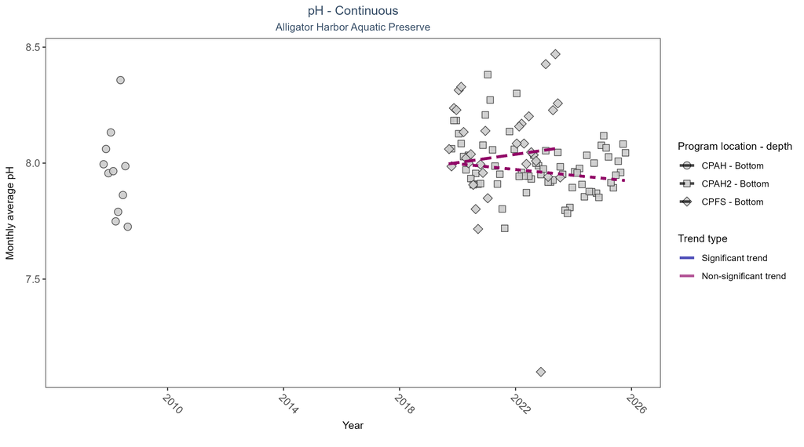

Scatter plot of monthly average pH over time at continuously monitored program locations. Each location is analyzed separately, with significant (blue) or non-significant (magenta) trend lines shown for time series that included five or more years of observations.

Seasonal Kendall-Tau Results for pH - All Stations

| Program Location | Statistical Trend | No. of Samples | No. Years with Data | Period of Record | Median Result Value | Tau | Sen Intercept | Sen Slope | P |
| --- | --- | --- | --- | --- | --- | --- | --- | --- | --- |
| CPAH | Insufficient data to calculate trend | 13034 | 2 | 2007 - 2008 | 7.9 | - | - | - | - |
| CPAH2 | No significant trend | 172942 | 7 | 2019 - 2025 | 8.0 | -0.18 | 8.01 | -0.01 | 0.09 |
| CPFS | No significant trend | 61868 | 5 | 2019 - 2023 | 8.1 | 0.19 | 7.98 | 0.02 | 0.52 |

No detectable change in monthly average pH was observed at two locations. There was insufficient data to fit a model for one location.

### Dissolved Oxygen Saturation - Continuous

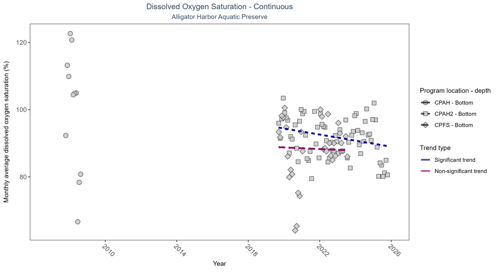

Scatter plot of monthly average dissolved oxygen saturation over time at continuously monitored program locations. Each location is analyzed separately, with significant (blue) or non-significant (magenta) trend lines shown for time series that included five or more years of observations.

Seasonal Kendall-Tau Results for Dissolved Oxygen Saturation - All Stations

| Program Location | Statistical Trend | No. of Samples | No. Years with Data | Period of Record | Median Result Value | Tau | Sen Intercept | Sen Slope | P |
| --- | --- | --- | --- | --- | --- | --- | --- | --- | --- |
| CPAH | Insufficient data to calculate trend | 11557 | 2 | 2007 - 2008 | 105.6 | - | - | - | - |
| CPAH2 | Significantly decreasing trend | 175461 | 7 | 2019 - 2025 | 93.0 | -0.27 | 95.3 | -0.91 | 0.01 |
| CPFS | No significant trend | 56928 | 5 | 2019 - 2023 | 90.7 | 0.02 | 89.01 | -0.24 | 1 |

### Dissolved Oxygen - Continuous

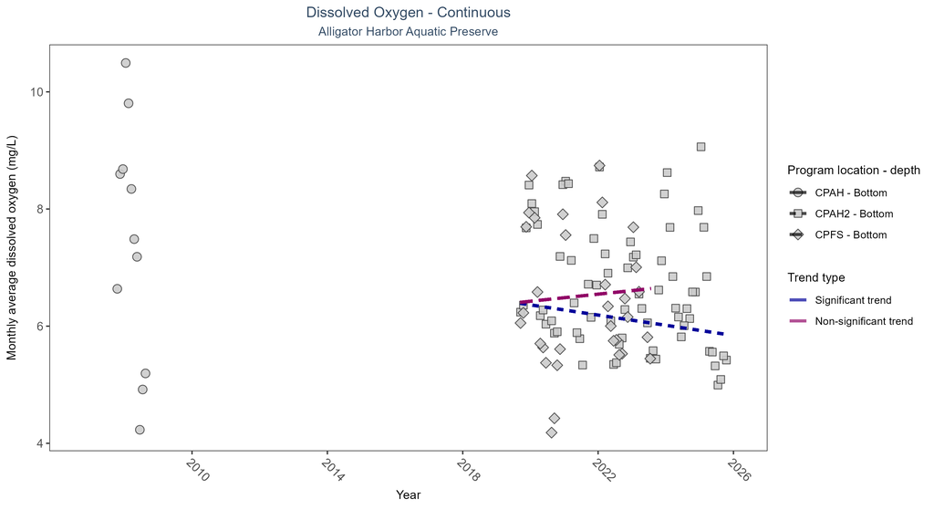

Scatter plot of monthly average dissolved oxygen over time at continuously monitored program locations. Each location is analyzed separately, with significant (blue) or non-significant (magenta) trend lines shown for time series that included five or more years of observations.

Seasonal Kendall-Tau Results for Dissolved Oxygen - All Stations

| Program Location | Statistical Trend | No. of Samples | No. Years with Data | Period of Record | Median Result Value | Tau | Sen Intercept | Sen Slope | P |
| --- | --- | --- | --- | --- | --- | --- | --- | --- | --- |
| CPAH | Insufficient data to calculate trend | 11557 | 2 | 2007 - 2008 | 8.0 | - | - | - | - |
| CPAH2 | Significantly decreasing trend | 175461 | 7 | 2019 - 2025 | 6.7 | -0.24 | 6.45 | -0.09 | 0.02 |
| CPFS | No significant trend | 56853 | 5 | 2019 - 2023 | 6.4 | 0.12 | 6.36 | 0.06 | 0.74 |

At one program location, monthly average dissolved oxygen decreased by 0.09 mg/L per year. No detectable change in monthly average dissolved oxygen was observed at one location. There was insufficient data to fit a model for one location.

### Turbidity - Continuous

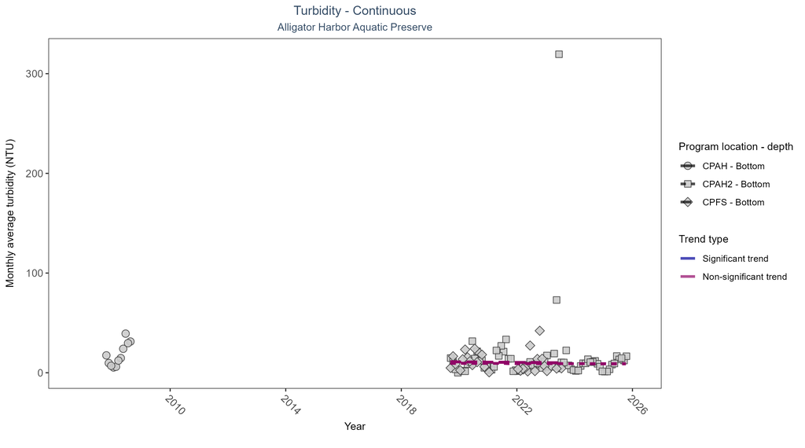

Scatter plot of monthly average turbidity over time at continuously monitored program locations. Each location is analyzed separately, with significant (blue) or non-significant (magenta) trend lines shown for time series that included five or more years of observations.

Seasonal Kendall-Tau Results for Turbidity - All Stations

| Program Location | Statistical Trend | No. of Samples | No. Years with Data | Period of Record | Median Result Value | Tau | Sen Intercept | Sen Slope | P |
| --- | --- | --- | --- | --- | --- | --- | --- | --- | --- |
| CPAH | Insufficient data to calculate trend | 12558 | 2 | 2007 - 2008 | 10 | - | - | - | - |
| CPAH2 | No significant trend | 176505 | 7 | 2019 - 2025 | 6 | -0.03 | 9.58 | -0.09 | 0.8 |
| CPFS | No significant trend | 55980 | 5 | 2019 - 2023 | 3 | -0.16 | 11.21 | -0.26 | 1 |

No detectable change in monthly average turbidity was observed at two locations. There was insufficient data to fit a model for one location.

### Water Temperature - Continuous

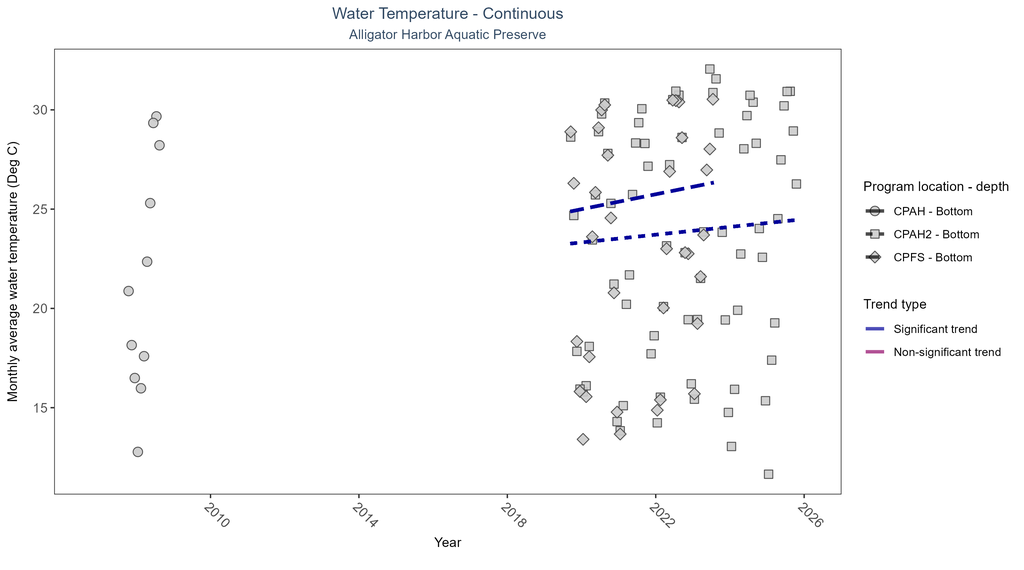

Scatter plot of monthly average water temperature over time at continuously monitored program locations. Each location is analyzed separately, with significant (blue) or non-significant (magenta) trend lines shown for time series that included five or more years of observations.

Seasonal Kendall-Tau Results for Water Temperature - All Stations

| Program Location | Statistical Trend | No. of Samples | No. Years with Data | Period of Record | Median Result Value | Tau | Sen Intercept | Sen Slope | P |
| --- | --- | --- | --- | --- | --- | --- | --- | --- | --- |
| CPAH | Insufficient data to calculate trend | 13034 | 2 | 2007 - 2008 | 20.9 | - | - | - | - |
| CPAH2 | Significantly increasing trend | 189604 | 7 | 2019 - 2025 | 23.7 | 0.22 | 23.13 | 0.2 | 0.05 |
| CPFS | Significantly increasing trend | 80801 | 5 | 2019 - 2023 | 24.1 | 0.37 | 24.62 | 0.38 | 0.03 |

At two program locations, monthly average water temperature increased by 0.2°C per year at one site and by 0.38°C per year at the other. There was insufficient data to fit a model for one location.

### Salinity - Continuous

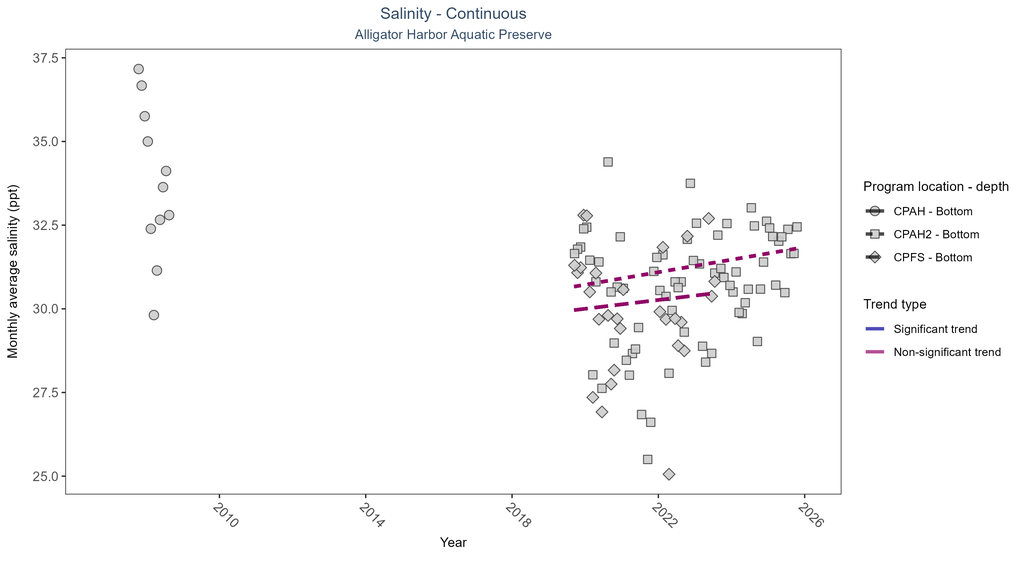

Scatter plot of monthly average salinity over time at continuously monitored program locations. Each location is analyzed separately, with significant (blue) or non-significant (magenta) trend lines shown for time series that included five or more years of observations.

Seasonal Kendall-Tau Results for Salinity - All Stations

| Program Location | Statistical Trend | No. of Samples | No. Years with Data | Period of Record | Median Result Value | Tau | Sen Intercept | Sen Slope | P |
| --- | --- | --- | --- | --- | --- | --- | --- | --- | --- |
| CPAH | Insufficient data to calculate trend | 13034 | 2 | 2007 - 2008 | 34.0 | - | - | - | - |
| CPAH2 | No significant trend | 171623 | 7 | 2019 - 2025 | 31.0 | 0.18 | 30.53 | 0.19 | 0.1 |
| CPFS | No significant trend | 60346 | 5 | 2019 - 2023 | 30.5 | 0 | 29.87 | 0.13 | 1 |

No detectable change in monthly average salinity was observed at two locations. There was insufficient data to fit a model for one location.

### Specific Conductivity - Continuous

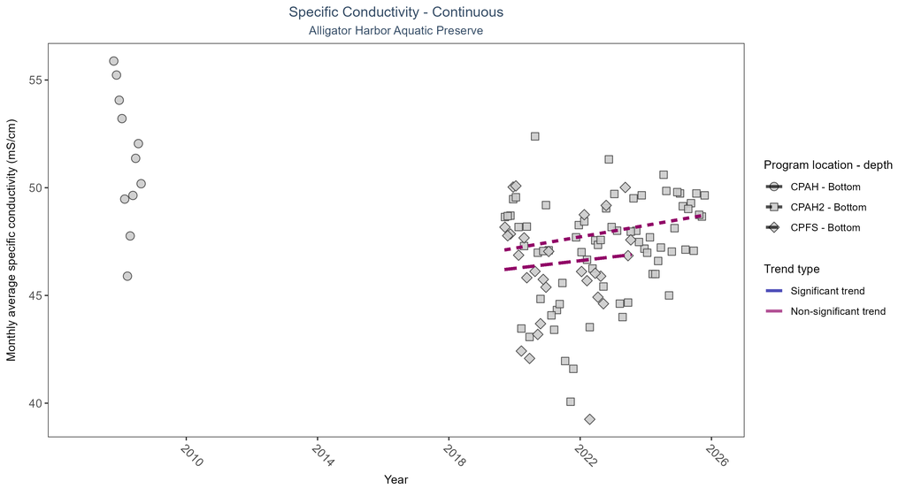

Scatter plot of monthly average specific conductivity over time at continuously monitored program locations. Each location is analyzed separately, with significant (blue) or non-significant (magenta) trend lines shown for time series that included five or more years of observations.

Seasonal Kendall-Tau Results for Specific Conductivity - All Stations

| Program Location | Statistical Trend | No. of Samples | No. Years with Data | Period of Record | Median Result Value | Tau | Sen Intercept | Sen Slope | P |
| --- | --- | --- | --- | --- | --- | --- | --- | --- | --- |
| CPAH | Insufficient data to calculate trend | 13034 | 2 | 2007 - 2008 | 51.89 | - | - | - | - |
| CPAH2 | No significant trend | 171623 | 7 | 2019 - 2025 | 47.71 | 0.21 | 46.93 | 0.27 | 0.06 |
| CPFS | No significant trend | 60346 | 5 | 2019 - 2023 | 46.91 | 0 | 46.08 | 0.18 | 1 |

No detectable change in monthly average specific conductivity was observed at two locations. There was insufficient data to fit a model for one location.

# Submerged Aquatic Vegetation

The data file used is: **All_SAV_Parameters-2026-Jun-04.txt**

**Submerged aquatic vegetation** (*SAV*) refers to plants and plant-like macroalgae species that live entirely underwater. The two primary categories of *SAV* inhabiting Florida estuaries are *benthic macroalgae* and *seagrasses*. They often grow together in dense beds or meadows that carpet the seafloor. *Macroalgae* include multicellular species of green, red and brown algae that often live attached to the substrate by a holdfast. They tend to grow quickly and can tolerate relatively high nutrient levels, making them a threat to seagrasses and other benthic habitats in areas with poor water quality. In contrast, *seagrasses* are grass-like, vascular, flowering plants that are attached to the seafloor by extensive root systems. *Seagrasses* occur throughout the coastal areas of Florida, including protected bays and lagoons as well as deeper offshore waters on the continental shelf. *Seagrasses* have taken advantage of the broad, shallow shelf and clear water to produce two of the most extensive seagrass beds anywhere in continental North America.

## Parameters

**Percent Cover** measures the fraction of an area of seafloor that is covered by SAV, usually estimated by evaluating multiple small areas of seafloor. Percent cover is often estimated for total SAV, individual types of vegetation (seagrass, attached algae, drift algae) and individual species.

**Frequency of Occurrence** was calculated as the number of times a taxon was observed in a year divided by the number of sampling events, multiplied by 100. Analysis is conducted at the quadrat level and is inclusive of all quadrats (i.e., quadrats evaluated using Braun-Blanquet, modified Braun-Blanquet, and percent cover.”

## Species

**Turtle grass** (*Thalassia testudinum*) is the largest of the Florida seagrasses, with longer, thicker blades and deeper root structures than any of the other seagrasses. It is considered a climax seagrass species.

**Shoal grass** (*Halodule wrightii*) is an early colonizer of vegetated areas and usually grows in water too shallow for other species except *widgeon grass*. It can often tolerate larger salinity ranges than other seagrass species. *Shoal grass* is characterized by thin, flat blades, that are narrower than *turtle grass* blades.

**Manatee grass** (*Syringodium filiforme*) is easily recognizable because its leaves are thin and cylindrical instead of the flat, ribbon-like form shared by many other seagrass species. The leaves can grow up to half a meter in length. *Manatee grass* is usually found in mixed seagrass beds or small, dense monospecific patches.

**Widgeon grass** (*Ruppia maritima*) grows in both fresh and salt water and is widely distributed throughout Florida’s estuaries in less saline areas, particularly in inlets along the east coast. This species resembles *shoal grass* in certain environments but can be identified by the pointed tips of its leaves.

Three species of *Halophila spp.* are found in Florida - **Star grass** (*Halophila engelmannii*), **Paddle grass** (*Halophila decipiens*), and **Johnson’s seagrass** (*Halophila johnsonii*). These are smaller, more fragile seagrasses than other Florida species and are considered ephemeral. They grow along a single long rhizome, with short blades. These species are not well-studied, although surveys are underway to define their ecological roles.

### Notes

*Star grass*, *Paddle grass*, and *Johnson’s seagrass* will be grouped together and listed as **Halophila spp.** in the following managed areas. This is because several surveys did not specify to the species level:

- Banana River Aquatic Preserve
- Indian River-Malabar to Vero Beach Aquatic Preserve
- Indian River-Vero Beach to Ft. Pierce Aquatic Preserve
- Jensen Beach to Jupiter Inlet Aquatic Preserve
- Loxahatchee River-Lake Worth Creek Aquatic Preserve
- Mosquito Lagoon Aquatic Preserve
- Biscayne Bay Aquatic Preserve
- Florida Keys National Marine Sanctuary

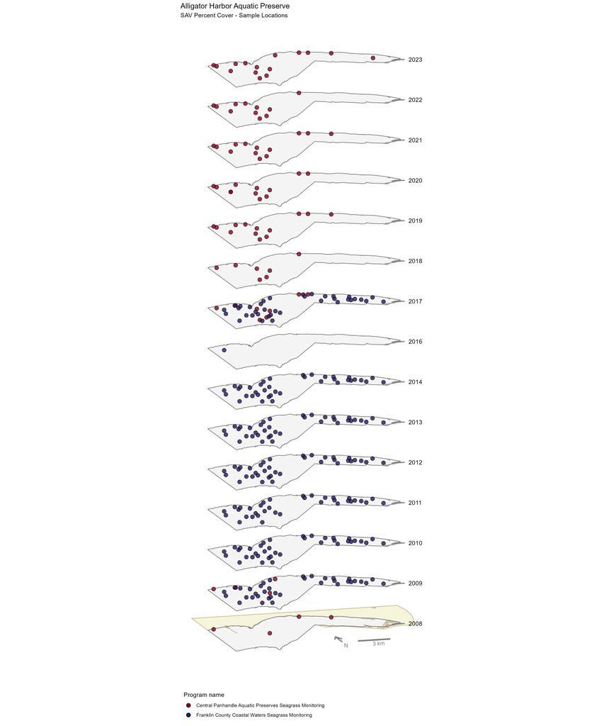

Maps showing the temporal scope of SAV sampling sites within the boundaries of *Alligator Harbor Aquatic Preserve* by program name.

Click [here](https://github.com/FloridaSEACAR/SEACAR_Trend_Analyses/tree/main/SAV/output/SAV_temporal_scope_plots) to view spatio-temporal plots on GitHub.